# Risk Factor Analysis

## Outcome Variable

**Outcome Variable:** swasted

## Predictor Variables

**Intervention Variable:** hhwealth_quart

**Adjustment Set:**

- arm
- sex
- W_mage
- meducyrs
- feducyrs
- W_gagebrth
- W_birthwt
- W_birthlen
- W_nchldlt5
- W_parity
- delta_W_mage
- delta_meducyrs
- delta_feducyrs
- delta_W_gagebrth
- delta_W_birthwt
- delta_W_birthlen
- delta_W_nchldlt5
- delta_W_parity

## Stratifying Variables

The analysis was stratified on these variable(s):

- agecat
- studyid
- country

## Data Summary

| agecat | studyid | country | hhwealth_quart | swasted | n_cell | n |
| --- | --- | --- | --- | --- | --- | --- |
| Birth | CMC-V-BCS-2002 | INDIA | Wealth Q4 | 0 | 31 | 86 |
| Birth | CMC-V-BCS-2002 | INDIA | Wealth Q4 | 1 | 1 | 86 |
| Birth | CMC-V-BCS-2002 | INDIA | Wealth Q1 | 0 | 13 | 86 |
| Birth | CMC-V-BCS-2002 | INDIA | Wealth Q1 | 1 | 0 | 86 |
| Birth | CMC-V-BCS-2002 | INDIA | Wealth Q2 | 0 | 19 | 86 |
| Birth | CMC-V-BCS-2002 | INDIA | Wealth Q2 | 1 | 0 | 86 |
| Birth | CMC-V-BCS-2002 | INDIA | Wealth Q3 | 0 | 22 | 86 |
| Birth | CMC-V-BCS-2002 | INDIA | Wealth Q3 | 1 | 0 | 86 |
| Birth | COHORTS | GUATEMALA | Wealth Q4 | 0 | 232 | 729 |
| Birth | COHORTS | GUATEMALA | Wealth Q4 | 1 | 26 | 729 |
| Birth | COHORTS | GUATEMALA | Wealth Q1 | 0 | 132 | 729 |
| Birth | COHORTS | GUATEMALA | Wealth Q1 | 1 | 12 | 729 |
| Birth | COHORTS | GUATEMALA | Wealth Q2 | 0 | 134 | 729 |
| Birth | COHORTS | GUATEMALA | Wealth Q2 | 1 | 7 | 729 |
| Birth | COHORTS | GUATEMALA | Wealth Q3 | 0 | 174 | 729 |
| Birth | COHORTS | GUATEMALA | Wealth Q3 | 1 | 12 | 729 |
| Birth | COHORTS | PHILIPPINES | Wealth Q4 | 0 | 769 | 2898 |
| Birth | COHORTS | PHILIPPINES | Wealth Q4 | 1 | 46 | 2898 |
| Birth | COHORTS | PHILIPPINES | Wealth Q1 | 0 | 618 | 2898 |
| Birth | COHORTS | PHILIPPINES | Wealth Q1 | 1 | 29 | 2898 |
| Birth | COHORTS | PHILIPPINES | Wealth Q2 | 0 | 491 | 2898 |
| Birth | COHORTS | PHILIPPINES | Wealth Q2 | 1 | 15 | 2898 |
| Birth | COHORTS | PHILIPPINES | Wealth Q3 | 0 | 899 | 2898 |
| Birth | COHORTS | PHILIPPINES | Wealth Q3 | 1 | 31 | 2898 |
| Birth | CONTENT | PERU | Wealth Q4 | 0 | 0 | 2 |
| Birth | CONTENT | PERU | Wealth Q4 | 1 | 0 | 2 |
| Birth | CONTENT | PERU | Wealth Q1 | 0 | 0 | 2 |
| Birth | CONTENT | PERU | Wealth Q1 | 1 | 0 | 2 |
| Birth | CONTENT | PERU | Wealth Q2 | 0 | 1 | 2 |
| Birth | CONTENT | PERU | Wealth Q2 | 1 | 0 | 2 |

[output cut: 386 more lines]

The following strata were considered:

- agecat: 24 months, studyid: CMC-V-BCS-2002, country: INDIA
- agecat: 24 months, studyid: COHORTS, country: GUATEMALA
- agecat: 24 months, studyid: COHORTS, country: PHILIPPINES
- agecat: 24 months, studyid: CONTENT, country: PERU
- agecat: 24 months, studyid: GMS-Nepal, country: NEPAL
- agecat: 24 months, studyid: IRC, country: INDIA
- agecat: 24 months, studyid: JiVitA-3, country: BANGLADESH
- agecat: 24 months, studyid: JiVitA-4, country: BANGLADESH
- agecat: 24 months, studyid: LCNI-5, country: MALAWI
- agecat: 24 months, studyid: MAL-ED, country: BANGLADESH
- agecat: 24 months, studyid: MAL-ED, country: BRAZIL
- agecat: 24 months, studyid: MAL-ED, country: INDIA
- agecat: 24 months, studyid: MAL-ED, country: NEPAL
- agecat: 24 months, studyid: MAL-ED, country: PERU
- agecat: 24 months, studyid: MAL-ED, country: SOUTH AFRICA
- agecat: 24 months, studyid: MAL-ED, country: TANZANIA, UNITED REPUBLIC OF
- agecat: 24 months, studyid: PROVIDE, country: BANGLADESH
- agecat: 24 months, studyid: TanzaniaChild2, country: TANZANIA, UNITED REPUBLIC OF
- agecat: 6 months, studyid: CMC-V-BCS-2002, country: INDIA
- agecat: 6 months, studyid: COHORTS, country: GUATEMALA
- agecat: 6 months, studyid: COHORTS, country: PHILIPPINES
- agecat: 6 months, studyid: CONTENT, country: PERU
- agecat: 6 months, studyid: GMS-Nepal, country: NEPAL
- agecat: 6 months, studyid: IRC, country: INDIA
- agecat: 6 months, studyid: JiVitA-3, country: BANGLADESH
- agecat: 6 months, studyid: JiVitA-4, country: BANGLADESH
- agecat: 6 months, studyid: LCNI-5, country: MALAWI
- agecat: 6 months, studyid: MAL-ED, country: BANGLADESH
- agecat: 6 months, studyid: MAL-ED, country: BRAZIL
- agecat: 6 months, studyid: MAL-ED, country: INDIA
- agecat: 6 months, studyid: MAL-ED, country: NEPAL
- agecat: 6 months, studyid: MAL-ED, country: PERU
- agecat: 6 months, studyid: MAL-ED, country: SOUTH AFRICA
- agecat: 6 months, studyid: MAL-ED, country: TANZANIA, UNITED REPUBLIC OF
- agecat: 6 months, studyid: PROVIDE, country: BANGLADESH
- agecat: 6 months, studyid: TanzaniaChild2, country: TANZANIA, UNITED REPUBLIC OF
- agecat: Birth, studyid: CMC-V-BCS-2002, country: INDIA
- agecat: Birth, studyid: COHORTS, country: GUATEMALA
- agecat: Birth, studyid: COHORTS, country: PHILIPPINES
- agecat: Birth, studyid: CONTENT, country: PERU
- agecat: Birth, studyid: GMS-Nepal, country: NEPAL
- agecat: Birth, studyid: IRC, country: INDIA
- agecat: Birth, studyid: JiVitA-3, country: BANGLADESH
- agecat: Birth, studyid: JiVitA-4, country: BANGLADESH
- agecat: Birth, studyid: MAL-ED, country: BANGLADESH
- agecat: Birth, studyid: MAL-ED, country: BRAZIL
- agecat: Birth, studyid: MAL-ED, country: INDIA
- agecat: Birth, studyid: MAL-ED, country: NEPAL
- agecat: Birth, studyid: MAL-ED, country: PERU
- agecat: Birth, studyid: MAL-ED, country: SOUTH AFRICA
- agecat: Birth, studyid: MAL-ED, country: TANZANIA, UNITED REPUBLIC OF
- agecat: Birth, studyid: PROVIDE, country: BANGLADESH

### Dropped Strata

Some strata were dropped due to rare outcomes:

- agecat: Birth, studyid: CMC-V-BCS-2002, country: INDIA
- agecat: Birth, studyid: CONTENT, country: PERU
- agecat: Birth, studyid: GMS-Nepal, country: NEPAL
- agecat: Birth, studyid: MAL-ED, country: BANGLADESH
- agecat: Birth, studyid: MAL-ED, country: BRAZIL
- agecat: Birth, studyid: MAL-ED, country: INDIA
- agecat: Birth, studyid: MAL-ED, country: NEPAL
- agecat: Birth, studyid: MAL-ED, country: PERU
- agecat: Birth, studyid: MAL-ED, country: SOUTH AFRICA
- agecat: Birth, studyid: MAL-ED, country: TANZANIA, UNITED REPUBLIC OF
- agecat: Birth, studyid: PROVIDE, country: BANGLADESH
- agecat: 6 months, studyid: CMC-V-BCS-2002, country: INDIA
- agecat: 6 months, studyid: COHORTS, country: GUATEMALA
- agecat: 6 months, studyid: CONTENT, country: PERU
- agecat: 6 months, studyid: GMS-Nepal, country: NEPAL
- agecat: 6 months, studyid: IRC, country: INDIA
- agecat: 6 months, studyid: JiVitA-4, country: BANGLADESH
- agecat: 6 months, studyid: LCNI-5, country: MALAWI
- agecat: 6 months, studyid: MAL-ED, country: BANGLADESH
- agecat: 6 months, studyid: MAL-ED, country: BRAZIL
- agecat: 6 months, studyid: MAL-ED, country: INDIA
- agecat: 6 months, studyid: MAL-ED, country: NEPAL
- agecat: 6 months, studyid: MAL-ED, country: PERU
- agecat: 6 months, studyid: MAL-ED, country: SOUTH AFRICA
- agecat: 6 months, studyid: MAL-ED, country: TANZANIA, UNITED REPUBLIC OF
- agecat: 6 months, studyid: PROVIDE, country: BANGLADESH
- agecat: 6 months, studyid: TanzaniaChild2, country: TANZANIA, UNITED REPUBLIC OF
- agecat: 24 months, studyid: CMC-V-BCS-2002, country: INDIA
- agecat: 24 months, studyid: COHORTS, country: GUATEMALA
- agecat: 24 months, studyid: COHORTS, country: PHILIPPINES
- agecat: 24 months, studyid: CONTENT, country: PERU
- agecat: 24 months, studyid: GMS-Nepal, country: NEPAL
- agecat: 24 months, studyid: IRC, country: INDIA
- agecat: 24 months, studyid: LCNI-5, country: MALAWI
- agecat: 24 months, studyid: MAL-ED, country: BANGLADESH
- agecat: 24 months, studyid: MAL-ED, country: BRAZIL
- agecat: 24 months, studyid: MAL-ED, country: INDIA
- agecat: 24 months, studyid: MAL-ED, country: NEPAL
- agecat: 24 months, studyid: MAL-ED, country: PERU
- agecat: 24 months, studyid: MAL-ED, country: SOUTH AFRICA
- agecat: 24 months, studyid: MAL-ED, country: TANZANIA, UNITED REPUBLIC OF
- agecat: 24 months, studyid: PROVIDE, country: BANGLADESH
- agecat: 24 months, studyid: TanzaniaChild2, country: TANZANIA, UNITED REPUBLIC OF

## Methods Detail

We’re interested in the causal parameters $E[Y_a]$ for all values of $a \in \mathcal{A}$. These parameters represent the mean outcome if, possibly contrary to fact, we intervened to set all units to have $A=a$. Under the randomization and positivity assumptions, these are identified by the statistical parameters $\psi_a=E_W[E_{Y|A,W}(Y|A=a,W)]$. In addition, we’re interested in the mean of $Y$, $E[Y]$ under no intervention (the observed mean). We will estimate these parameters by using SuperLearner to fit the relevant likelihood factors – $E_{Y|A,W}(Y|A=a,W)$ and $p(A=a|W)$, and then updating our likelihood fit using a joint TMLE.

For unadjusted analyses ($W=\{\}$), initial likelihoods were estimated using Lrnr_glm to estimate the simple $E(Y|A)$ and Lrnr_mean to estimate $p(A)$. For adjusted analyses, a small library containing Lrnr_glmnet, Lrnr_xgboost, and Lrnr_mean was used.

Having estimated these parameters, we will then use the delta method to estimate relative risks and attributable risks relative to a prespecified baseline level of $A$.

# Results Detail

## Results Plots

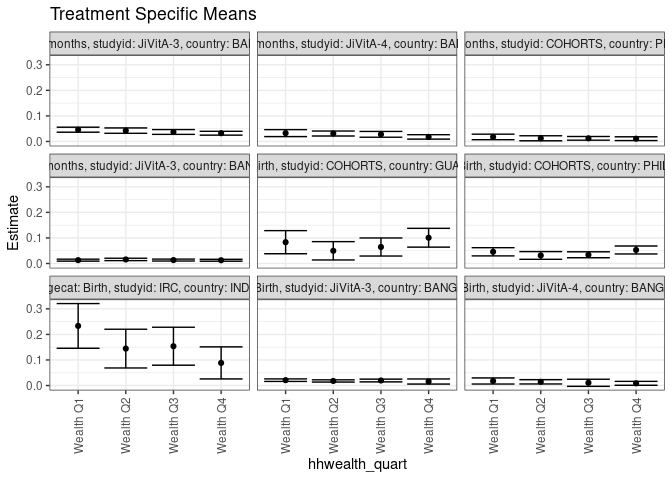

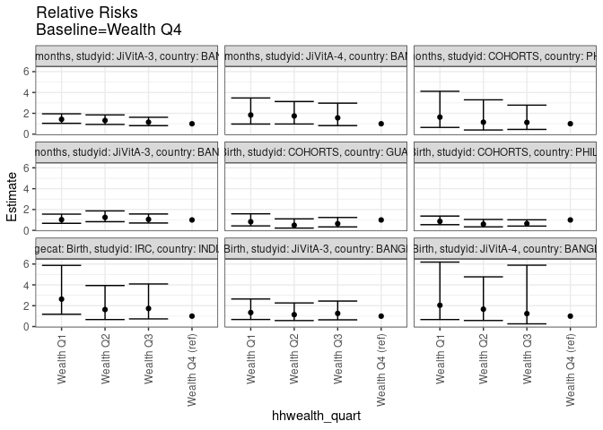

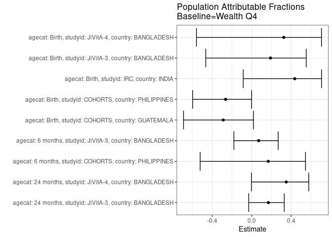

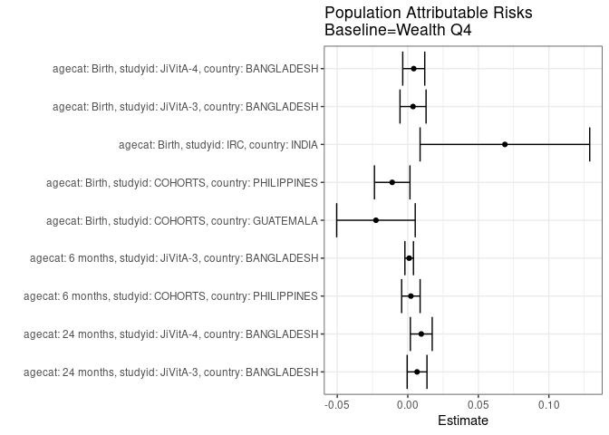

## Results Table

### Parameter: TSM

| agecat | studyid | country | intervention_level | baseline_level | estimate | ci_lower | ci_upper |
| --- | --- | --- | --- | --- | --- | --- | --- |
| Birth | COHORTS | GUATEMALA | Wealth Q4 | NA | 0.1007752 | 0.0640176 | 0.1375328 |
| Birth | COHORTS | GUATEMALA | Wealth Q1 | NA | 0.0833333 | 0.0381602 | 0.1285064 |
| Birth | COHORTS | GUATEMALA | Wealth Q2 | NA | 0.0496454 | 0.0137682 | 0.0855226 |
| Birth | COHORTS | GUATEMALA | Wealth Q3 | NA | 0.0645161 | 0.0291863 | 0.0998460 |
| Birth | COHORTS | PHILIPPINES | Wealth Q4 | NA | 0.0528137 | 0.0371782 | 0.0684492 |
| Birth | COHORTS | PHILIPPINES | Wealth Q1 | NA | 0.0457577 | 0.0296526 | 0.0618629 |
| Birth | COHORTS | PHILIPPINES | Wealth Q2 | NA | 0.0314653 | 0.0163766 | 0.0465539 |
| Birth | COHORTS | PHILIPPINES | Wealth Q3 | NA | 0.0341095 | 0.0225054 | 0.0457136 |
| Birth | IRC | INDIA | Wealth Q4 | NA | 0.0886076 | 0.0258514 | 0.1513638 |
| Birth | IRC | INDIA | Wealth Q1 | NA | 0.2333333 | 0.1458244 | 0.3208423 |
| Birth | IRC | INDIA | Wealth Q2 | NA | 0.1445783 | 0.0688105 | 0.2203461 |
| Birth | IRC | INDIA | Wealth Q3 | NA | 0.1538462 | 0.0796076 | 0.2280847 |
| Birth | JiVitA-3 | BANGLADESH | Wealth Q4 | NA | 0.0156914 | 0.0057416 | 0.0256412 |
| Birth | JiVitA-3 | BANGLADESH | Wealth Q1 | NA | 0.0210641 | 0.0161486 | 0.0259797 |
| Birth | JiVitA-3 | BANGLADESH | Wealth Q2 | NA | 0.0179409 | 0.0136007 | 0.0222810 |
| Birth | JiVitA-3 | BANGLADESH | Wealth Q3 | NA | 0.0197684 | 0.0144184 | 0.0251185 |
| Birth | JiVitA-4 | BANGLADESH | Wealth Q4 | NA | 0.0087413 | 0.0010883 | 0.0163942 |
| Birth | JiVitA-4 | BANGLADESH | Wealth Q1 | NA | 0.0178571 | 0.0059026 | 0.0298117 |
| Birth | JiVitA-4 | BANGLADESH | Wealth Q2 | NA | 0.0145867 | 0.0061829 | 0.0229906 |
| Birth | JiVitA-4 | BANGLADESH | Wealth Q3 | NA | 0.0108527 | -0.0030676 | 0.0247731 |
| 6 months | COHORTS | PHILIPPINES | Wealth Q4 | NA | 0.0107527 | 0.0033404 | 0.0181650 |
| 6 months | COHORTS | PHILIPPINES | Wealth Q1 | NA | 0.0175747 | 0.0067761 | 0.0283733 |
| 6 months | COHORTS | PHILIPPINES | Wealth Q2 | NA | 0.0123711 | 0.0025319 | 0.0222103 |
| 6 months | COHORTS | PHILIPPINES | Wealth Q3 | NA | 0.0121145 | 0.0049976 | 0.0192315 |
| 6 months | JiVitA-3 | BANGLADESH | Wealth Q4 | NA | 0.0126818 | 0.0089862 | 0.0163774 |
| 6 months | JiVitA-3 | BANGLADESH | Wealth Q1 | NA | 0.0130397 | 0.0091865 | 0.0168928 |
| 6 months | JiVitA-3 | BANGLADESH | Wealth Q2 | NA | 0.0158265 | 0.0111608 | 0.0204922 |
| 6 months | JiVitA-3 | BANGLADESH | Wealth Q3 | NA | 0.0133681 | 0.0095355 | 0.0172008 |
| 24 months | JiVitA-3 | BANGLADESH | Wealth Q4 | NA | 0.0321855 | 0.0246497 | 0.0397213 |
| 24 months | JiVitA-3 | BANGLADESH | Wealth Q1 | NA | 0.0459055 | 0.0361194 | 0.0556916 |
| 24 months | JiVitA-3 | BANGLADESH | Wealth Q2 | NA | 0.0423323 | 0.0318085 | 0.0528561 |
| 24 months | JiVitA-3 | BANGLADESH | Wealth Q3 | NA | 0.0370581 | 0.0277169 | 0.0463992 |
| 24 months | JiVitA-4 | BANGLADESH | Wealth Q4 | NA | 0.0177188 | 0.0090475 | 0.0263902 |
| 24 months | JiVitA-4 | BANGLADESH | Wealth Q1 | NA | 0.0325615 | 0.0189580 | 0.0461651 |
| 24 months | JiVitA-4 | BANGLADESH | Wealth Q2 | NA | 0.0309571 | 0.0212782 | 0.0406359 |
| 24 months | JiVitA-4 | BANGLADESH | Wealth Q3 | NA | 0.0277394 | 0.0164032 | 0.0390756 |

### Parameter: E(Y)

| agecat | studyid | country | intervention_level | baseline_level | estimate | ci_lower | ci_upper |
| --- | --- | --- | --- | --- | --- | --- | --- |
| Birth | COHORTS | GUATEMALA | NA | NA | 0.0781893 | 0.0586874 | 0.0976912 |
| Birth | COHORTS | PHILIPPINES | NA | NA | 0.0417529 | 0.0344692 | 0.0490367 |
| Birth | IRC | INDIA | NA | NA | 0.1574344 | 0.1188345 | 0.1960344 |
| Birth | JiVitA-3 | BANGLADESH | NA | NA | 0.0193954 | 0.0169846 | 0.0218061 |
| Birth | JiVitA-4 | BANGLADESH | NA | NA | 0.0129490 | 0.0075258 | 0.0183723 |
| 6 months | COHORTS | PHILIPPINES | NA | NA | 0.0129342 | 0.0086762 | 0.0171922 |
| 6 months | JiVitA-3 | BANGLADESH | NA | NA | 0.0136505 | 0.0115778 | 0.0157231 |
| 24 months | JiVitA-3 | BANGLADESH | NA | NA | 0.0387480 | 0.0344217 | 0.0430742 |
| 24 months | JiVitA-4 | BANGLADESH | NA | NA | 0.0272727 | 0.0220640 | 0.0324815 |

### Parameter: RR

| agecat | studyid | country | intervention_level | baseline_level | estimate | ci_lower | ci_upper |
| --- | --- | --- | --- | --- | --- | --- | --- |
| Birth | COHORTS | GUATEMALA | Wealth Q4 | Wealth Q4 | 1.0000000 | 1.0000000 | 1.000000 |
| Birth | COHORTS | GUATEMALA | Wealth Q1 | Wealth Q4 | 0.8269231 | 0.4302403 | 1.589348 |
| Birth | COHORTS | GUATEMALA | Wealth Q2 | Wealth Q4 | 0.4926350 | 0.2192618 | 1.106847 |
| Birth | COHORTS | GUATEMALA | Wealth Q3 | Wealth Q4 | 0.6401985 | 0.3315606 | 1.236136 |
| Birth | COHORTS | PHILIPPINES | Wealth Q4 | Wealth Q4 | 1.0000000 | 1.0000000 | 1.000000 |
| Birth | COHORTS | PHILIPPINES | Wealth Q1 | Wealth Q4 | 0.8663993 | 0.5474837 | 1.371087 |
| Birth | COHORTS | PHILIPPINES | Wealth Q2 | Wealth Q4 | 0.5957783 | 0.3393380 | 1.046012 |
| Birth | COHORTS | PHILIPPINES | Wealth Q3 | Wealth Q4 | 0.6458463 | 0.4117734 | 1.012978 |
| Birth | IRC | INDIA | Wealth Q4 | Wealth Q4 | 1.0000000 | 1.0000000 | 1.000000 |
| Birth | IRC | INDIA | Wealth Q1 | Wealth Q4 | 2.6333333 | 1.1815569 | 5.868904 |
| Birth | IRC | INDIA | Wealth Q2 | Wealth Q4 | 1.6316695 | 0.6760758 | 3.937939 |
| Birth | IRC | INDIA | Wealth Q3 | Wealth Q4 | 1.7362637 | 0.7369189 | 4.090832 |
| Birth | JiVitA-3 | BANGLADESH | Wealth Q4 | Wealth Q4 | 1.0000000 | 1.0000000 | 1.000000 |
| Birth | JiVitA-3 | BANGLADESH | Wealth Q1 | Wealth Q4 | 1.3423997 | 0.6810946 | 2.645796 |
| Birth | JiVitA-3 | BANGLADESH | Wealth Q2 | Wealth Q4 | 1.1433561 | 0.5767933 | 2.266433 |
| Birth | JiVitA-3 | BANGLADESH | Wealth Q3 | Wealth Q4 | 1.2598260 | 0.6485141 | 2.447382 |
| Birth | JiVitA-4 | BANGLADESH | Wealth Q4 | Wealth Q4 | 1.0000000 | 1.0000000 | 1.000000 |
| Birth | JiVitA-4 | BANGLADESH | Wealth Q1 | Wealth Q4 | 2.0428571 | 0.6744880 | 6.187308 |
| Birth | JiVitA-4 | BANGLADESH | Wealth Q2 | Wealth Q4 | 1.6687196 | 0.5835866 | 4.771572 |
| Birth | JiVitA-4 | BANGLADESH | Wealth Q3 | Wealth Q4 | 1.2415504 | 0.2617888 | 5.888133 |
| 6 months | COHORTS | PHILIPPINES | Wealth Q4 | Wealth Q4 | 1.0000000 | 1.0000000 | 1.000000 |
| 6 months | COHORTS | PHILIPPINES | Wealth Q1 | Wealth Q4 | 1.6344464 | 0.6491256 | 4.115405 |
| 6 months | COHORTS | PHILIPPINES | Wealth Q2 | Wealth Q4 | 1.1505155 | 0.4016045 | 3.295993 |
| 6 months | COHORTS | PHILIPPINES | Wealth Q3 | Wealth Q4 | 1.1266520 | 0.4554533 | 2.786992 |
| 6 months | JiVitA-3 | BANGLADESH | Wealth Q4 | Wealth Q4 | 1.0000000 | 1.0000000 | 1.000000 |
| 6 months | JiVitA-3 | BANGLADESH | Wealth Q1 | Wealth Q4 | 1.0282151 | 0.6791326 | 1.556730 |
| 6 months | JiVitA-3 | BANGLADESH | Wealth Q2 | Wealth Q4 | 1.2479632 | 0.8336865 | 1.868103 |
| 6 months | JiVitA-3 | BANGLADESH | Wealth Q3 | Wealth Q4 | 1.0541176 | 0.7068347 | 1.572028 |
| 24 months | JiVitA-3 | BANGLADESH | Wealth Q4 | Wealth Q4 | 1.0000000 | 1.0000000 | 1.000000 |
| 24 months | JiVitA-3 | BANGLADESH | Wealth Q1 | Wealth Q4 | 1.4262804 | 1.0404606 | 1.955169 |
| 24 months | JiVitA-3 | BANGLADESH | Wealth Q2 | Wealth Q4 | 1.3152606 | 0.9336951 | 1.852757 |
| 24 months | JiVitA-3 | BANGLADESH | Wealth Q3 | Wealth Q4 | 1.1513910 | 0.8169942 | 1.622657 |
| 24 months | JiVitA-4 | BANGLADESH | Wealth Q4 | Wealth Q4 | 1.0000000 | 1.0000000 | 1.000000 |
| 24 months | JiVitA-4 | BANGLADESH | Wealth Q1 | Wealth Q4 | 1.8376777 | 0.9720554 | 3.474143 |
| 24 months | JiVitA-4 | BANGLADESH | Wealth Q2 | Wealth Q4 | 1.7471272 | 0.9749108 | 3.131008 |
| 24 months | JiVitA-4 | BANGLADESH | Wealth Q3 | Wealth Q4 | 1.5655309 | 0.8232464 | 2.977100 |

### Parameter: PAR

| agecat | studyid | country | intervention_level | baseline_level | estimate | ci_lower | ci_upper |
| --- | --- | --- | --- | --- | --- | --- | --- |
| Birth | COHORTS | GUATEMALA | Wealth Q4 | NA | -0.0225859 | -0.0504264 | 0.0052547 |
| Birth | COHORTS | PHILIPPINES | Wealth Q4 | NA | -0.0110608 | -0.0236439 | 0.0015224 |
| Birth | IRC | INDIA | Wealth Q4 | NA | 0.0688268 | 0.0087091 | 0.1289445 |
| Birth | JiVitA-3 | BANGLADESH | Wealth Q4 | NA | 0.0037040 | -0.0055315 | 0.0129394 |
| Birth | JiVitA-4 | BANGLADESH | Wealth Q4 | NA | 0.0042078 | -0.0035932 | 0.0120088 |
| 6 months | COHORTS | PHILIPPINES | Wealth Q4 | NA | 0.0021815 | -0.0043653 | 0.0087283 |
| 6 months | JiVitA-3 | BANGLADESH | Wealth Q4 | NA | 0.0009686 | -0.0020662 | 0.0040035 |
| 24 months | JiVitA-3 | BANGLADESH | Wealth Q4 | NA | 0.0065625 | -0.0004647 | 0.0135897 |
| 24 months | JiVitA-4 | BANGLADESH | Wealth Q4 | NA | 0.0095539 | 0.0018157 | 0.0172920 |

### Parameter: PAF

| agecat | studyid | country | intervention_level | baseline_level | estimate | ci_lower | ci_upper |
| --- | --- | --- | --- | --- | --- | --- | --- |
| Birth | COHORTS | GUATEMALA | Wealth Q4 | NA | -0.2888617 | -0.6914201 | 0.0178877 |
| Birth | COHORTS | PHILIPPINES | Wealth Q4 | NA | -0.2649097 | -0.5990872 | -0.0005687 |
| Birth | IRC | INDIA | Wealth Q4 | NA | 0.4371777 | -0.0857091 | 0.7082377 |
| Birth | JiVitA-3 | BANGLADESH | Wealth Q4 | NA | 0.1909712 | -0.4660135 | 0.5535323 |
| Birth | JiVitA-4 | BANGLADESH | Wealth Q4 | NA | 0.3249492 | -0.5605657 | 0.7079946 |
| 6 months | COHORTS | PHILIPPINES | Wealth Q4 | NA | 0.1686636 | -0.5227820 | 0.5461463 |
| 6 months | JiVitA-3 | BANGLADESH | Wealth Q4 | NA | 0.0709587 | -0.1807193 | 0.2689899 |
| 24 months | JiVitA-3 | BANGLADESH | Wealth Q4 | NA | 0.1693632 | -0.0301483 | 0.3302348 |
| 24 months | JiVitA-4 | BANGLADESH | Wealth Q4 | NA | 0.3503089 | -0.0024974 | 0.5789530 |